# Behind the Stars: Was Fandango’s Rating System Biased?

Fandango’s displayed ratings against Rotten Tomatoes, Metacritic, and IMDb, 2015

## 1 Introduction

If you are deciding whether to see a movie, how much should you trust the rating displayed on the ticket-selling site itself? This is the question FiveThirtyEight raised in its 2015 investigation, *Be Suspicious of Online Movie Ratings, Especially Fandango’s* (Hickey 2015), after noticing that Fandango’s displayed star ratings looked implausibly high compared to the underlying numeric ratings and to other review platforms. Fandango sells movie tickets directly, which gives it a financial incentive that a pure review aggregator, like Rotten Tomatoes or Metacritic, does not have: a higher displayed rating can plausibly drive more ticket sales.

This report follows that investigation using the same data FiveThirtyEight collected. It first checks whether Fandango’s own displayed star rating matches the true underlying rating implied by its votes. It then compares Fandango’s scores against Rotten Tomatoes, Metacritic, and IMDb, first pairwise for each platform’s own critic-versus-user split, and then all together on a common 0-5 scale, to see whether the earlier finding was specific to Fandango’s own display logic or reflects Fandango’s ratings running high relative to the rest of the market.

## 2 Data

The data comes from FiveThirtyEight’s public GitHub repository, pulled directly from Fandango on 2015-08-24 (FiveThirtyEight 2015). Two files are used. The first, `fandango_scrape.csv`, contains every film Fandango displayed a rating for: the film title, the number of stars shown on the page (`STARS`), the actual average rating pulled from the page’s HTML (`RATING`), and the number of user votes (`VOTES`) at the time of the pull. The second, `all_sites_scores.csv`, contains the subset of those films that also had a Rotten Tomatoes critic score (`RottenTomatoes`) and user score (`RottenTomatoes_User`), a Metacritic critic score (`Metacritic`) and user score (`Metacritic_User`), an IMDb user score (`IMDB`), and at least 30 Fandango fan reviews, along with the Metacritic and IMDb user vote counts.

```python
style_table(
    fandango.describe().reset_index().rename(columns={"index": "statistic"}),
    formats={"STARS": "{:.2f}", "RATING": "{:.2f}", "VOTES": "{:,.0f}"},
)
```

Table 1: Fandango scrape summary statistics, all 504 films

| statistic | STARS | RATING | VOTES |
| --- | --- | --- | --- |
| count | 504.00 | 504.00 | 504 |
| mean | 3.56 | 3.38 | 1,148 |
| std | 1.56 | 1.49 | 3,831 |
| min | 0.00 | 0.00 | 0 |
| 25% | 3.50 | 3.10 | 3 |
| 50% | 4.00 | 3.80 | 18 |
| 75% | 4.50 | 4.30 | 190 |
| max | 5.00 | 5.00 | 34,846 |

`STARS` and `RATING` are nearly identical on average (3.56 versus 3.38), a first hint that Fandango’s displayed rating runs a little above the number it is supposedly built from. `VOTES` is heavily right-skewed: half the films have 18 or fewer votes, while the busiest film has over 34,000. The three numeric columns correlate as expected: `STARS` and `RATING` move together almost perfectly (0.99), while `VOTES` correlates weakly with either (0.16), so popularity and rating are largely independent of each other.

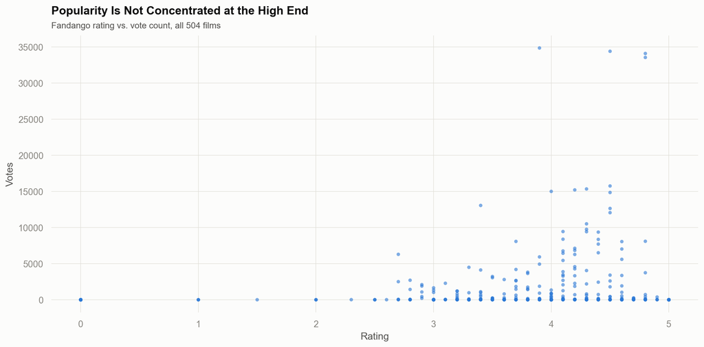

Figure 1: Fandango rating versus vote count, all 504 films

```python
fig, ax = plt.subplots()
ax.scatter(fandango["RATING"], fandango["VOTES"], s=18, alpha=0.6, color=SITE_COLORS["RATING"], edgecolor="none")
ax.set_xlabel("Rating")
ax.set_ylabel("Votes")
add_title(ax, "Popularity Is Not Concentrated at the High End", "Fandango rating vs. vote count, all 504 films")
fig.tight_layout()
```

The film titles follow a consistent `Title (Year)` format, which makes the release year straightforward to pull out for a quick sanity check on the data’s coverage.

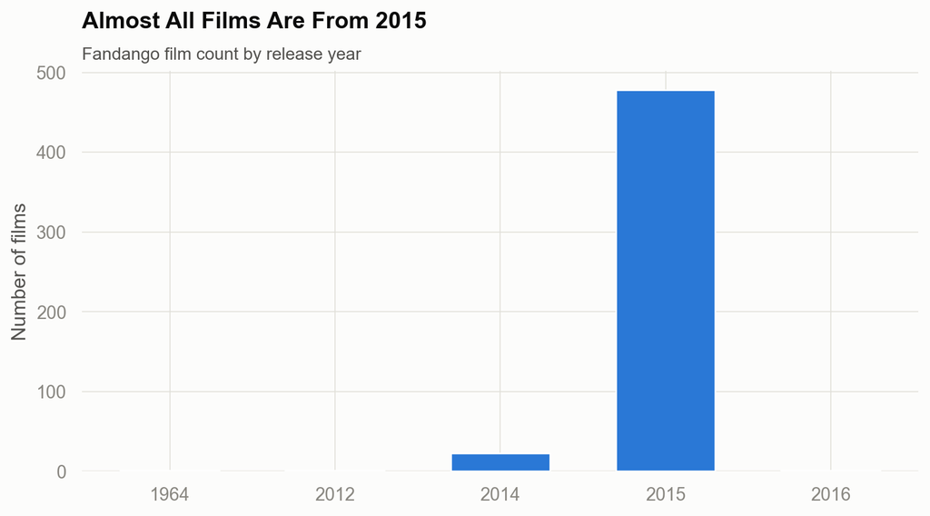

Figure 2: Film count by release year

```python
fandango["YEAR"] = fandango["FILM"].apply(lambda title: title.split("(")[-1].replace(")", ""))
year_counts = fandango["YEAR"].value_counts().sort_index()

fig, ax = plt.subplots(figsize=(8, 4.5))
ax.bar(year_counts.index, year_counts.values, color=SITE_COLORS["RATING"], width=0.6)
ax.set_xlabel(None)
ax.set_ylabel("Number of films")
add_title(ax, "Almost All Films Are From 2015", "Fandango film count by release year")
fig.tight_layout()
```

478 of the 504 films (95%) are 2015 releases, consistent with the scrape being a snapshot of what was showing or recently released at the time. A handful of older titles (23 from 2014, and three isolated films from 2012, 1964, and 2016) round out the rest and do not meaningfully affect the analysis below.

```python
style_table(
    fandango.nlargest(10, "VOTES")[["FILM", "STARS", "RATING", "VOTES"]],
    formats={"STARS": "{:.1f}", "RATING": "{:.1f}", "VOTES": "{:,.0f}"},
)
```

Table 2: 10 most-voted films on Fandango

| FILM | STARS | RATING | VOTES |
| --- | --- | --- | --- |
| Fifty Shades of Grey (2015) | 4.0 | 3.9 | 34,846 |
| Jurassic World (2015) | 4.5 | 4.5 | 34,390 |
| American Sniper (2015) | 5.0 | 4.8 | 34,085 |
| Furious 7 (2015) | 5.0 | 4.8 | 33,538 |
| Inside Out (2015) | 4.5 | 4.5 | 15,749 |
| The Hobbit: The Battle of the Five Armies (2014) | 4.5 | 4.3 | 15,337 |
| Kingsman: The Secret Service (2015) | 4.5 | 4.2 | 15,205 |
| Minions (2015) | 4.0 | 4.0 | 14,998 |
| Avengers: Age of Ultron (2015) | 5.0 | 4.5 | 14,846 |
| Into the Woods (2014) | 3.5 | 3.4 | 13,055 |

69 of the 504 films have zero votes, meaning Fandango is displaying a rating with no underlying user data behind it at all. Those films are excluded from the rest of the analysis, leaving 435 films with at least one vote, referred to below as the reviewed films.

## 3 Fandango’s Displayed Stars vs. True Rating

As FiveThirtyEight’s reporting noted, the star rating a site displays is not always the same number as the underlying average rating: HTML rendering and rounding choices can introduce a gap between the two. The chart below compares the distribution of Fandango’s displayed `STARS` against the distribution of the true `RATING`, for the 435 reviewed films.

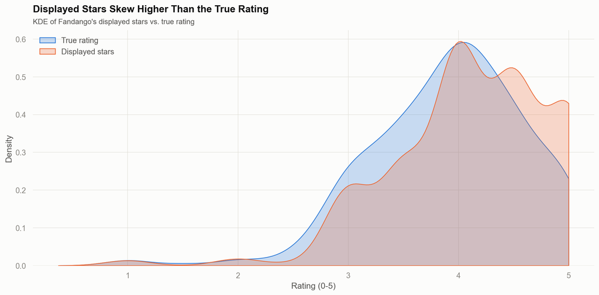

Figure 3: Distribution of Fandango’s displayed stars vs. true rating, 435 reviewed films

```python
fig, ax = plt.subplots()
sns.kdeplot(data=fan_reviewed, x="RATING", clip=(0, 5), fill=True, color=SITE_COLORS["RATING"], label="True rating", ax=ax)
sns.kdeplot(data=fan_reviewed, x="STARS", clip=(0, 5), fill=True, color=SITE_COLORS["STARS"], label="Displayed stars", ax=ax)
ax.set_xlabel("Rating (0-5)")
ax.set_ylabel("Density")
ax.legend(loc="upper left")
add_title(ax, "Displayed Stars Skew Higher Than the True Rating", "KDE of Fandango's displayed stars vs. true rating")
fig.tight_layout()
```

The displayed-stars curve sits visibly to the right of the true-rating curve, concentrated toward 4 and 4.5 stars, while the true rating spreads more evenly across the 3 to 4.5 range. Quantifying this directly, as the displayed stars minus the true rating:

```python
fan_reviewed["STARS_DIFF"] = (fan_reviewed["STARS"] - fan_reviewed["RATING"]).round(2)

style_table(
    fan_reviewed["STARS_DIFF"].describe().reset_index().rename(columns={"index": "statistic", "STARS_DIFF": "value"}),
    formats={"value": "{:.3f}"},
)
```

Table 3: Fandango displayed stars minus true rating, summary statistics

| statistic | value |
| --- | --- |
| count | 435.000 |
| mean | 0.212 |
| std | 0.169 |
| min | 0.000 |
| 25% | 0.100 |
| 50% | 0.200 |
| 75% | 0.300 |
| max | 1.000 |

The gap is never negative: Fandango’s displayed rating is never lower than the true rating for any of the 435 reviewed films, and it is strictly higher for 328 of them (75%), with the rest displaying exactly the true rating. The largest single-film gap is a full star:

```python
style_table(
    fan_reviewed[fan_reviewed["STARS_DIFF"] == fan_reviewed["STARS_DIFF"].max()][["FILM", "STARS", "RATING", "STARS_DIFF"]],
    formats={"STARS": "{:.1f}", "RATING": "{:.1f}", "STARS_DIFF": "{:.2f}"},
)
```

Table 4: Largest gap between displayed stars and true rating

| FILM | STARS | RATING | STARS_DIFF |
| --- | --- | --- | --- |
| Turbo Kid (2015) | 5.0 | 4.0 | 1.00 |

*Turbo Kid* displayed 5.0 stars against a true rating of 4.0, the single largest discrepancy found on Fandango’s own site, before any comparison to other platforms.

## 4 Fandango vs. Other Rating Platforms

This section sets Fandango aside and looks at how the other three platforms compare internally, each of which reports separate critic and user scores.

### 4.1 Rotten Tomatoes

Rotten Tomatoes reports a critics’ Tomatometer score and a separate audience score, both on a 0-100 scale.

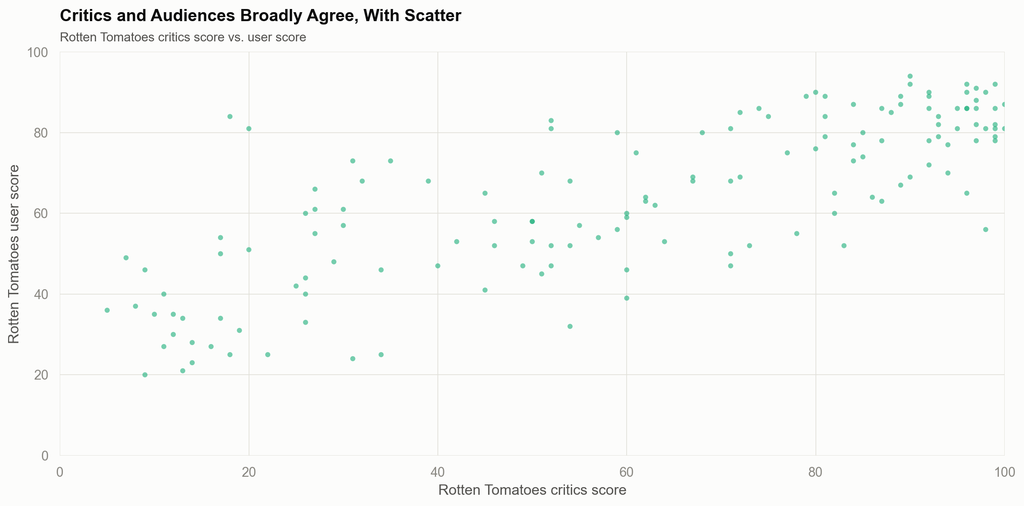

Figure 4: Rotten Tomatoes critics score vs. user score, 146 films

```python
fig, ax = plt.subplots()
ax.scatter(all_sites["RottenTomatoes"], all_sites["RottenTomatoes_User"], s=18, alpha=0.6, color=SITE_COLORS["RT_Norm"], edgecolor="none")
ax.set_xlim(0, 100)
ax.set_ylim(0, 100)
ax.set_xlabel("Rotten Tomatoes critics score")
ax.set_ylabel("Rotten Tomatoes user score")
add_title(ax, "Critics and Audiences Broadly Agree, With Scatter", "Rotten Tomatoes critics score vs. user score")
fig.tight_layout()
```

Quantifying the spread, the critics’ score minus the user score averages -3.0 points (near zero, so no systematic critic-versus-audience bias on average), but the *absolute* difference averages 15.1 points on the 0-100 scale, meaning individual films frequently see real disagreement even though it washes out in the average.

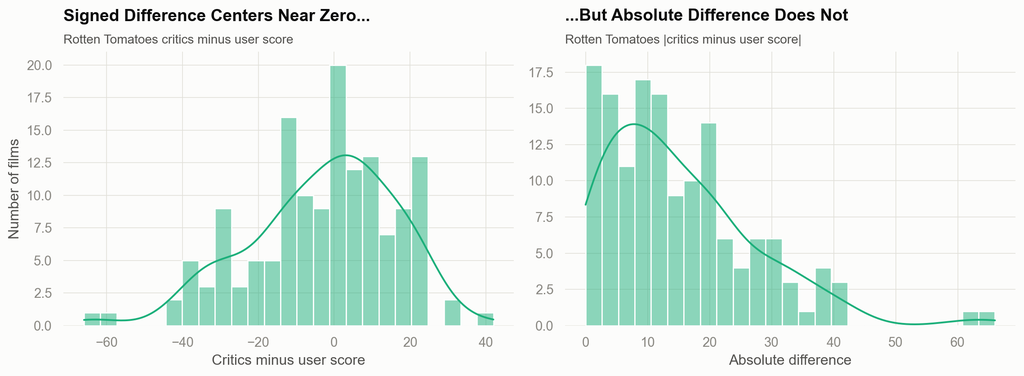

Figure 5: Rotten Tomatoes critics score minus user score, signed and absolute

```python
fig, axes = plt.subplots(1, 2, figsize=(12, 4.5))
sns.histplot(data=all_sites, x="Rotten_Diff", kde=True, bins=25, color=SITE_COLORS["RT_Norm"], ax=axes[0])
axes[0].set_xlabel("Critics minus user score")
axes[0].set_ylabel("Number of films")
sns.histplot(x=all_sites["Rotten_Diff"].abs(), kde=True, bins=25, color=SITE_COLORS["RT_Norm"], ax=axes[1])
axes[1].set_xlabel("Absolute difference")
axes[1].set_ylabel(None)
add_title(axes[0], "Signed Difference Centers Near Zero...", "Rotten Tomatoes critics minus user score")
add_title(axes[1], "...But Absolute Difference Does Not", "Rotten Tomatoes |critics minus user score|")
fig.tight_layout()
```

```python
rt_users_love = all_sites.nsmallest(5, "Rotten_Diff")[["FILM", "Rotten_Diff"]].assign(direction="Users rated higher")
rt_critics_love = all_sites.nlargest(5, "Rotten_Diff")[["FILM", "Rotten_Diff"]].assign(direction="Critics rated higher")
style_table(pd.concat([rt_users_love, rt_critics_love]), formats={"Rotten_Diff": "{:+.0f}"})
```

Table 5: Largest critic-audience gaps on Rotten Tomatoes, both directions

| FILM | Rotten_Diff | direction |
| --- | --- | --- |
| Do You Believe? (2015) | -66 | Users rated higher |
| Little Boy (2015) | -61 | Users rated higher |
| Hitman: Agent 47 (2015) | -42 | Users rated higher |
| The Longest Ride (2015) | -42 | Users rated higher |
| The Wedding Ringer (2015) | -39 | Users rated higher |
| Mr. Turner (2014) | +42 | Critics rated higher |
| It Follows (2015) | +31 | Critics rated higher |
| While We're Young (2015) | +31 | Critics rated higher |
| Welcome to Me (2015) | +24 | Critics rated higher |
| I'll See You In My Dreams (2015) | +24 | Critics rated higher |

*Do You Believe?* shows the largest gap in either direction: users rated it 66 points higher than critics did. *Mr. Turner* shows the opposite pattern most strongly, with critics rating it 42 points above users.

### 4.2 Metacritic

Metacritic also splits its rating into a critic score (0-100) and a separate user score (0-10).

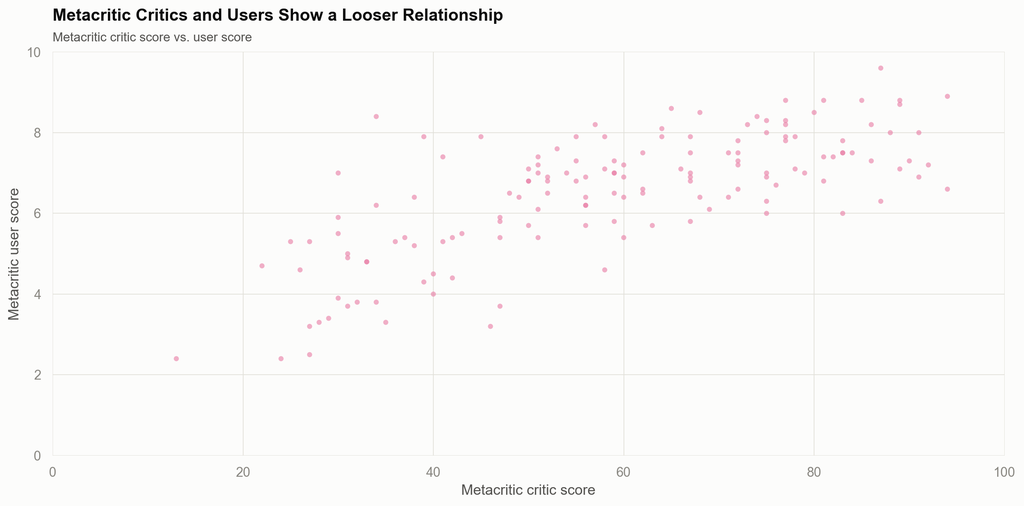

Figure 6: Metacritic critic score vs. user score, 146 films

```python
fig, ax = plt.subplots()
ax.scatter(all_sites["Metacritic"], all_sites["Metacritic_User"], s=18, alpha=0.6, color=SITE_COLORS["Meta_Norm"], edgecolor="none")
ax.set_xlim(0, 100)
ax.set_ylim(0, 10)
ax.set_xlabel("Metacritic critic score")
ax.set_ylabel("Metacritic user score")
add_title(ax, "Metacritic Critics and Users Show a Looser Relationship", "Metacritic critic score vs. user score")
fig.tight_layout()
```

### 4.3 IMDb and Vote Counts

Both Metacritic and IMDb report how many user votes back their score, which makes it possible to check whether the two platforms’ audiences are drawing from the same pool of viewers.

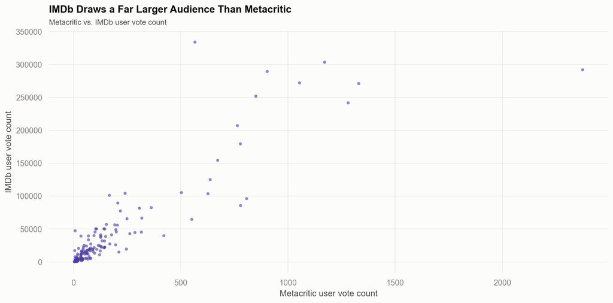

Figure 7: Metacritic user vote count vs. IMDb user vote count, 146 films

```python
fig, ax = plt.subplots()
ax.scatter(all_sites["Metacritic_user_vote_count"], all_sites["IMDB_user_vote_count"], s=18, alpha=0.6, color=SITE_COLORS["IMDB_Norm"], edgecolor="none")
ax.set_xlabel("Metacritic user vote count")
ax.set_ylabel("IMDb user vote count")
add_title(ax, "IMDb Draws a Far Larger Audience Than Metacritic", "Metacritic vs. IMDb user vote count")
fig.tight_layout()
```

```python
style_table(
    pd.concat([
        all_sites.nlargest(1, "IMDB_user_vote_count")[["FILM", "IMDB_user_vote_count", "Metacritic_user_vote_count"]],
        all_sites.nlargest(1, "Metacritic_user_vote_count")[["FILM", "IMDB_user_vote_count", "Metacritic_user_vote_count"]],
    ]),
    formats={"IMDB_user_vote_count": "{:,.0f}", "Metacritic_user_vote_count": "{:,.0f}"},
)
```

Table 6: Highest vote count on each platform

| FILM | IMDB_user_vote_count | Metacritic_user_vote_count |
| --- | --- | --- |
| The Imitation Game (2014) | 334,164 | 566 |
| Mad Max: Fury Road (2015) | 292,023 | 2,375 |

## 5 Fandango Against All Platforms: The Central Comparison

The previous sections established two things separately: Fandango’s own displayed stars run above its true rating, and the other three platforms show normal critic-versus-user disagreement without a consistent direction. This section brings all platforms onto one common scale to test the question that motivated the original investigation directly: does Fandango’s displayed rating run high not just against its own true rating, but against the rest of the market.

Rotten Tomatoes and Metacritic report on a 0-100 scale, Metacritic’s user score and IMDb report on a 0-10 scale, and Fandango displays 0-5 stars. To compare them directly, every score is rescaled to Fandango’s 0-5 range, preserving each score’s relative position on its own scale.

145 of the 146 films in `all_sites_scores.csv` also appear in the Fandango file under an identical title string; one, *Mission: Impossible – Rogue Nation*, is excluded because the two files encode its title with different dash characters and so do not merge on an exact match. This affects one film out of 146 and does not change the pattern below.

```python
norm_means = norm_scores.mean().reset_index()
norm_means.columns = ["column", "mean_score"]
norm_means["platform"] = norm_means["column"].map(SITE_LABELS)
style_table(norm_means[["platform", "mean_score"]], formats={"mean_score": "{:.2f}"})
```

Table 7: Mean normalized score by platform, 0-5 scale, 145 films

| platform | mean_score |
| --- | --- |
| Fandango (displayed) | 4.09 |
| Fandango (true) | 3.84 |
| Rotten Tomatoes (critics) | 3.03 |
| Rotten Tomatoes (users) | 3.18 |
| Metacritic (critics) | 2.94 |
| Metacritic (users) | 3.25 |
| IMDb | 3.37 |

Fandango’s displayed `STARS` has the highest mean of any column, 4.09, ahead of its own true `RATING` (3.84) and well ahead of every other platform, which range from 2.94 (Metacritic critics) to 3.37 (IMDb).

Averages can be pulled by a handful of outliers, so it is worth checking whether Fandango’s lead holds up film by film, not just on average. For each other platform, the table below counts how often Fandango’s displayed stars actually beat that platform’s normalized score for the same film.

```python
other_cols = ["RT_Norm", "RTU_Norm", "Meta_Norm", "Meta_U_Norm", "IMDB_Norm"]
win_rate = pd.DataFrame({
    "platform": [SITE_LABELS[c] for c in other_cols],
    "% of films": [(df["STARS"] > df[c]).mean() * 100 for c in other_cols],
})
style_table(win_rate, formats={"% of films": "{:.0f}%"})
```

Table 8: Share of films where Fandango’s displayed stars exceed each platform’s normalized score

| platform | % of films |
| --- | --- |
| Rotten Tomatoes (critics) | 67% |
| Rotten Tomatoes (users) | 88% |
| Metacritic (critics) | 86% |
| Metacritic (users) | 86% |
| IMDb | 92% |

Fandango’s displayed stars beat Rotten Tomatoes’ critic score alone on 67% of films, the smallest gap of the five, and beat every one of the remaining four platforms on at least 86% of films. This is not a small-average, large-variance effect: Fandango’s displayed rating is higher than the comparison platform on a clear majority of films in every single case. The chart below shows the full distribution behind those means, not just the averages.

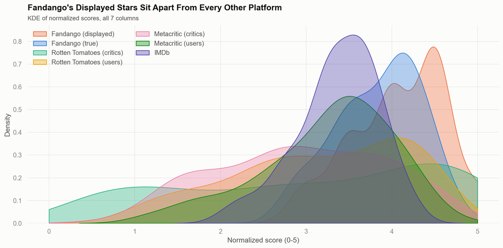

Figure 8: Distribution of normalized scores across all platforms, 145 films

```python
fig, ax = plt.subplots(figsize=(12, 6))
for col in norm_scores.columns:
    sns.kdeplot(data=norm_scores, x=col, clip=(0, 5), fill=True, alpha=0.35, color=SITE_COLORS[col], label=SITE_LABELS[col], ax=ax)
ax.set_xlabel("Normalized score (0-5)")
ax.set_ylabel("Density")
ax.legend(loc="upper left", ncol=2)
add_title(ax, "Fandango's Displayed Stars Sit Apart From Every Other Platform", "KDE of normalized scores, all 7 columns")
fig.tight_layout()
```

Fandango’s displayed stars are the only curve tightly concentrated near the top of the scale; every other platform, including Fandango’s own true rating, shows a wider, more left-of-center spread. Rotten Tomatoes’ critics score has the most even distribution of the group, making it the most useful single point of contrast against Fandango’s displayed stars.

[figure not shown]

Figure 9: Rotten Tomatoes critics score vs. Fandango displayed stars

```python
fig, ax = plt.subplots()
sns.kdeplot(data=norm_scores, x="RT_Norm", clip=(0, 5), fill=True, color=SITE_COLORS["RT_Norm"], label=SITE_LABELS["RT_Norm"], ax=ax)
sns.kdeplot(data=norm_scores, x="STARS", clip=(0, 5), fill=True, color=SITE_COLORS["STARS"], label=SITE_LABELS["STARS"], ax=ax)
ax.set_xlabel("Normalized score (0-5)")
ax.set_ylabel("Density")
ax.legend(loc="upper left")
add_title(ax, "The Widest Gap Is Against Rotten Tomatoes' Critics", "Rotten Tomatoes critics score vs. Fandango displayed stars")
fig.tight_layout()
```

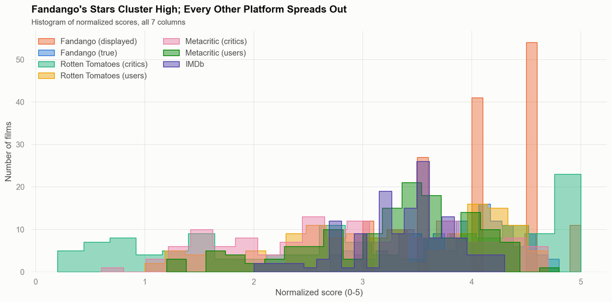

Figure 10: Histogram of normalized scores across all platforms, 145 films

```python
fig, ax = plt.subplots(figsize=(12, 6))
for col in norm_scores.columns:
    sns.histplot(data=norm_scores, x=col, bins=20, color=SITE_COLORS[col], label=SITE_LABELS[col], alpha=0.45, element="step", ax=ax)
ax.set_xlabel("Normalized score (0-5)")
ax.set_ylabel("Number of films")
ax.legend(loc="upper left", ncol=2)
add_title(ax, "Fandango's Stars Cluster High; Every Other Platform Spreads Out", "Histogram of normalized scores, all 7 columns")
fig.tight_layout()
```

A clustermap groups films by how similarly they score across all seven columns at once, which surfaces whether high and low scores travel together across platforms.

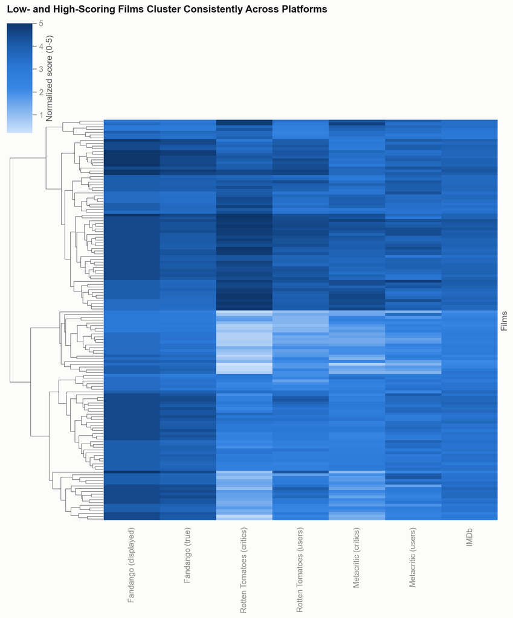

Figure 11: Clustermap of normalized scores across all platforms and films

```python
blue_cmap = LinearSegmentedColormap.from_list("fandango_blue", SEQUENTIAL_RAMP)
cg = sns.clustermap(
    norm_scores, cmap=blue_cmap, col_cluster=False, figsize=(10, 12),
    cbar_kws={"label": "Normalized score (0-5)"}, xticklabels=[SITE_LABELS[c] for c in norm_scores.columns],
    yticklabels=False,
)
cg.ax_heatmap.set_ylabel("Films")
cg.fig.suptitle("Low- and High-Scoring Films Cluster Consistently Across Platforms", x=0.02, y=1.01, ha="left", fontsize=14, fontweight="bold", color=COLOR_PRIMARY_INK)
plt.show()
```

```python
worst_films = df.nsmallest(10, "RT_Norm")[["FILM", "STARS", "RATING", "RT_Norm", "RTU_Norm", "Meta_Norm", "Meta_U_Norm", "IMDB_Norm"]]
style_table(worst_films, formats={c: "{:.1f}" for c in worst_films.columns if c != "FILM"})
```

Table 9: 10 lowest-rated films by Rotten Tomatoes critics, all normalized scores

| FILM | STARS | RATING | RT_Norm | RTU_Norm | Meta_Norm | Meta_U_Norm | IMDB_Norm |
| --- | --- | --- | --- | --- | --- | --- | --- |
| Paul Blart: Mall Cop 2 (2015) | 3.5 | 3.5 | 0.2 | 1.8 | 0.6 | 1.2 | 2.2 |
| Taken 3 (2015) | 4.5 | 4.1 | 0.4 | 2.3 | 1.3 | 2.3 | 3.0 |
| Fantastic Four (2015) | 3.0 | 2.7 | 0.4 | 1.0 | 1.4 | 1.2 | 2.0 |
| Hot Pursuit (2015) | 4.0 | 3.7 | 0.4 | 1.8 | 1.6 | 1.8 | 2.4 |
| Hitman: Agent 47 (2015) | 4.0 | 3.9 | 0.4 | 2.4 | 1.4 | 1.6 | 3.0 |
| The Boy Next Door (2015) | 4.0 | 3.6 | 0.5 | 1.8 | 1.5 | 2.8 | 2.3 |
| Seventh Son (2015) | 3.5 | 3.2 | 0.6 | 1.8 | 1.5 | 2.0 | 2.8 |
| Mortdecai (2015) | 3.5 | 3.2 | 0.6 | 1.5 | 1.4 | 1.6 | 2.8 |
| Sinister 2 (2015) | 3.5 | 3.3 | 0.6 | 1.7 | 1.6 | 2.5 | 2.8 |
| Unfinished Business (2015) | 3.5 | 3.2 | 0.6 | 1.4 | 1.6 | 1.9 | 2.7 |

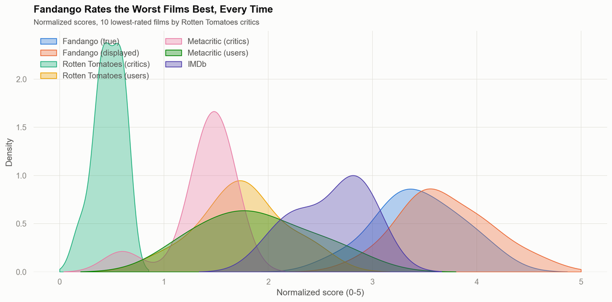

Figure 12: Distribution of normalized scores for the 10 lowest-rated films

```python
worst_scores = df.nsmallest(10, "RT_Norm")[list(SITE_COLORS.keys())]

fig, ax = plt.subplots(figsize=(12, 6))
for col in worst_scores.columns:
    sns.kdeplot(data=worst_scores, x=col, clip=(0, 5), fill=True, alpha=0.35, color=SITE_COLORS[col], label=SITE_LABELS[col], ax=ax)
ax.set_xlabel("Normalized score (0-5)")
ax.set_ylabel("Density")
ax.legend(loc="upper left", ncol=2)
add_title(ax, "Fandango Rates the Worst Films Best, Every Time", "Normalized scores, 10 lowest-rated films by Rotten Tomatoes critics")
fig.tight_layout()
```

### 5.1 Is the Inflation Concentrated in Obscure Films?

One remaining question is whether this inflation is spread evenly across Fandango’s catalog, or concentrated in lower-profile films where a padded rating is less likely to be noticed or challenged. `VOTES`, already established in the Data section as heavily right-skewed, gives a proxy for how much attention a film was getting at the time. The chart below plots each film’s inflation, Fandango’s displayed stars minus the mean of the other five platform-and-audience scores, against its vote count on a log scale.

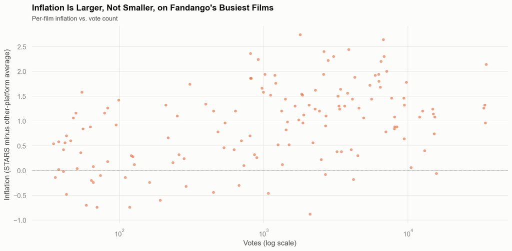

Figure 13: Fandango’s inflation vs. film popularity (vote count, log scale)

```python
df["other_platforms_avg"] = df[other_cols].mean(axis=1)
df["inflation"] = df["STARS"] - df["other_platforms_avg"]

log_votes = np.log1p(df["VOTES"])
inflation_r, inflation_p = stats.pearsonr(log_votes, df["inflation"])

fig, ax = plt.subplots()
ax.scatter(df["VOTES"], df["inflation"], s=22, alpha=0.6, color=SITE_COLORS["STARS"], edgecolor="none")
ax.set_xscale("log")
ax.axhline(0, color=COLOR_MUTED, linewidth=0.8, linestyle=":")
ax.set_xlabel("Votes (log scale)")
ax.set_ylabel("Inflation (STARS minus other-platform average)")
add_title(ax, "Inflation Is Larger, Not Smaller, on Fandango's Busiest Films", "Per-film inflation vs. vote count")
fig.tight_layout()
```

The relationship runs opposite to what a “padding goes unnoticed in the long tail” story would predict: inflation correlates positively with vote count on a log scale (r = 0.45, p < 0.001). Splitting the 145 films at the median vote count makes the same point in plainer terms: the less-voted half averages 0.63 stars of inflation, versus 1.24 stars for the more-voted half, almost double. Fandango’s displayed rating is not quietly padded on films few people are watching; the gap is, if anything, wider on the films with the most riding on them commercially.

```python
style_table(
    df.loc[df["FILM"].str.contains("Taken 3"), ["FILM", "STARS", "RATING", "RT_Norm", "RTU_Norm", "Meta_Norm", "Meta_U_Norm", "IMDB_Norm"]],
    formats={c: "{:.1f}" for c in ["STARS", "RATING", "RT_Norm", "RTU_Norm", "Meta_Norm", "Meta_U_Norm", "IMDB_Norm"]},
)
```

Table 10: Taken 3: Fandango’s displayed rating against every other platform

| FILM | STARS | RATING | RT_Norm | RTU_Norm | Meta_Norm | Meta_U_Norm | IMDB_Norm |
| --- | --- | --- | --- | --- | --- | --- | --- |
| Taken 3 (2015) | 4.5 | 4.1 | 0.4 | 2.3 | 1.3 | 2.3 | 3.0 |

**Final thoughts: Wow! Fandango is showing around 3-4 star ratings for films that are clearly bad! Notice the biggest offender, [Taken 3!](https://www.youtube.com/watch?v=tJrfImRCHJ0). Fandango is displaying 4.5 stars on their site for a film with an [average rating of 1.86](https://en.wikipedia.org/wiki/Taken_3#Critical_response) across the other platforms!**

[figure not shown]

Figure 14: *Taken 3* (2015): Fandango’s most emblematic case of displayed-rating inflation in this dataset.

## Appendices

**NoteReproducibility and data notes**

- Data pulled by FiveThirtyEight on 2015-08-24; see `README.md` for the source repository and column definitions.
- `fandango_scrape.csv`: 504 films, no missing values.
- `all_sites_scores.csv`: 146 films, no missing values.
- The Fandango-to-all-sites merge matches 145 of 146 films by exact title string; *Mission: Impossible – Rogue Nation* is dropped from the merged analysis only, due to a dash-character mismatch between the two files’ title columns.
- Normalization divides Rotten Tomatoes’ and Metacritic’s critic scores (0-100) by 20, and Metacritic’s and IMDb’s user scores (0-10) by 2, so every column lands on Fandango’s native 0-5 scale.

## References

FiveThirtyEight. 2015. “Fandango-Ratings Data.” https://github.com/fivethirtyeight/data/tree/master/fandango.

Hickey, Walt. 2015. “Be Suspicious of Online Movie Ratings, Especially Fandango’s.” https://fivethirtyeight.com/features/fandango-movies-ratings/.